# Boostrap confidence interval for % of protien different countries get from spices

Zackary Petrasek

September 6th, 2026

# 1 Introduction

I am going to conduct two different methods to find the 95% confidence interval for the mean level of spices used in different countries across the world. The first way I am going to do this is by using the entire data set and finding the confidence interval using that. The second way I am going to do this is by using the bootstrapping method to simulate samples from a sample of the original data sets and find the middle 95% quartile range of the means.

# 2 Materials

To do this I am going to use the Protein intake data set from Kaggle. This dataset is from a nutritional survey conducted around the peak of the COVID pandemic, which describes where different countries were getting their proetin intake from. As mentioned before I have chosen the spice variable, which in the context of this data set is the percent of protein different countries get from spices. So by finding the mean and confidence interval of this variable it will tell us on average what percent of people’s protein intake is coming from spices in their diet across the different countries in the world.

# 3 Methodology and Analysis

```r
library(readr)

url <- "https://raw.githubusercontent.com/ZackaryPetrasek/STA321/main/homeworks/hw1/w02-Protein_Supply_Quantity_Data.csv"

protein <- read_csv(url)
NCI <- t.test(protein$Spices, conf.level = 0.95)
```

The CI of the mean percent of protein that comes from spices is between 0.1820222% and 0.2815825%.

```r
spicesample<-sample(protein$Spices, 25, replace=FALSE)
### Did not see a specific number to use on the HW for size

mean.vector = NULL
for(i in 1:1000){
  samp <- sample(spicesample, 25, replace=TRUE)
  mean.vector[i]=mean(samp)
}
BCI = quantile(mean.vector, c(0.025, 0.975))
```

The 95% confidence interval gotten using the bootstrapping method was that the mean percent of protein that people from different countries around the world got from spice is between 0.1508265% and 0.4389902%

# 4 Results and Conclusions

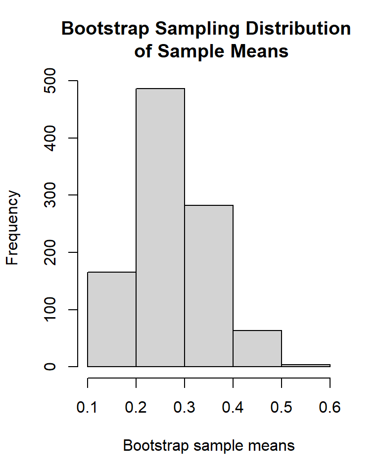

```r
hist(mean.vector, breaks = 4, xlab = "Bootstrap sample means", main="Bootstrap Sampling Distribution \n of Sample Means")
```

As stated earlier the 95% confidence interval for the entire data set is 0.1820222% and 0.2815825%. Which means that the mean percent of protein that comes from spices across different countries in the world we could estimate with 95% confidence to be between 0.1820222% and 0.2815825%. While the bootstrapping method provides a different confidence interval every time it runs, in general it has a larger range than the confidence interval for the entire set. For most of the times it runs it does cover most, if not all, of the original confidence interval gathered from the entire data set, but it usually goes further in either one or both directions. This is likely due to the fact that in a smaller sample of a larger data set if some extreme examples are present, due to how how bootstrapping works some of the 1000 samples of the sample will include multiple of the extreme values making the distribution more spread out, which then inflates the confidence interval.